# Introduction to Biostatistical Computing PHC 6937

Basic statistical inference in R

Haocheng Ding

Wednesday Nov 30th, 2022

# Outline

- Simulating random variables
- Basic hypothesis testing
- linear regression model

# Random samples from a given pool of numbers

```python
import random
a = range(1,11)
random.sample(a, 2)
```

```
## [8, 9]
```

```python
random.sample(a, 2)
```

```
## [2, 1]
```

```python
random.sample(a, 2)
```

```
## [10, 1]
```

# Are they really random? Can generate the same random number (for reproducibility)?

- The random numbers generated in Python are not truly random, they are **pseudorandom**.
- So we are able to reproduce the exact same random numbers by setting random seeds.

```python
import random
a = range(1,11)
random.seed(32611) ## 32611 can be replaced by any number.
random.sample(a,2)
```

```
## [3, 8]
```

```python
random.seed(32611) ## if you keep the same random seed, you will end up with the exact same result.
random.sample(a,2)
```

```
## [3, 8]
```

```python
random.seed(32608) ## if you update the random seed, you will end up with different result.
random.sample(a,2)
```

```
## [6, 7]
```

# Each time the seed is set, the same sequence follows

```python
random.seed(32611)
random.sample(range(1,11),2);random.sample(range(1,11),2);random.sample(range(1,11),2)
```

```
## [3, 8]
## [5, 9]
## [1, 9]
```

```python
random.seed(32611)
random.sample(range(1,11),2);random.sample(range(1,11),2);random.sample(range(1,11),2)
```

```
## [3, 8]
## [5, 9]
## [1, 9]
```

# Want to sample from a given pool of numbers with replacement

```python
import random
import string

random.sample(range(1,11),10) ## default is without replacement
```

```
## [5, 2, 4, 6, 8, 1, 9, 7, 3, 10]
```

```python
random.choices(range(1,11),k=10) ## with replacement
```

```
## [9, 4, 8, 8, 1, 8, 3, 2, 3, 2]
```

```python
random.choices(string.ascii_uppercase,k=10)
```

```
## ['N', 'C', 'I', 'T', 'I', 'M', 'M', 'Z', 'N', 'V']
```

# Random number generation from normal distribution

For normal distribution:

- numpy.random.normal(x, loc=0, scale=1): generate random variable from normal distribution. (rnorm() in R)

from scipy.stats import norm

- scipy.stats.norm.cdf(x, loc=0, scale=1): get CDF/pvalue from normal distribution, $\Phi(x)=(P(Z\leq x))$. (pnorm() in R)
- scipy.stats.norm.pdf(x, loc=0, scale=1): normal density function $\phi = \Phi'(x)$. (dnorm() in R)
- scipy.stats.norm.ppf(q, loc=0, scale=1): quantile function for normal distribution $q(y)=\Phi-1(y)$ such that $\Phi(q(y))=y$. (qnorm() in R)

# Random variable simulators in Python

| Distribution | Python command |
| --- | --- |
| Binomial | numpy.random.binomial |
| Poisson | numpy.random.poisson |
| Geometric | numpy.random.geometric |
| Negative binomial | numpy.random.negative_binomial |
| Uniform | numpy.random.uniform |
| Exponential | numpy.random.exponential |
| Normal | numpy.random.normal |
| Gamma | numpy.random.gamma |
| Beta | numpy.random.beta |
| Student t | numpy.random.standard_t |
| F | numpy.random.f |
| Chi-squared | numpy.random.chisquare |
| Weibull | numpy.random.weibull |
| Log-normal | numpy.random.lognormal |

# Random variable density in Python

| Distribution | Python command |
| --- | --- |
| Binomial | scipy.stats.binom.pdf |
| Poisson | scipy.stats.poisson.pmf |
| Geometric | scipy.stats.poisson.pdf |
| Negative binomial | scipy.stats.nbinom.pdf |
| Uniform | scipy.stats.uniform.pdf |
| Exponential | scipy.stats.expon.pdf |
| Normal | scipy.stats.norm.pdf |
| Gamma | scipy.stats.gamma.pdf |
| Beta | scipy.stats.beta.pdf |
| Student t | scipy.stats.t.pdf |
| F | scipy.stats.f.pdf |
| Chi-squared | scipy.stats.chi2.pdf |
| Weibull | scipy.stats.weibull_min.pdf |
| Log-normal | scipy.stats.lognorm.pdf |

# Random variable distribution tail probablity in Python

| Distribution | Python command |
| --- | --- |
| Binomial | scipy.stats.binom.cdf |
| Poisson | scipy.stats.poisson.cdf |
| Geometric | scipy.stats.poisson.cdf |
| Negative binomial | scipy.stats.nbinom.cdf |
| Uniform | scipy.stats.uniform.cdf |
| Exponential | scipy.stats.expon.cdf |
| Normal | scipy.stats.norm.cdf |
| Gamma | scipy.stats.gamma.cdf |
| Beta | scipy.stats.beta.cdf |
| Student t | scipy.stats.t.cdf |
| F | scipy.stats.f.cdf |
| Chi-squared | scipy.stats.chi2.cdf |
| Weibull | scipy.stats.weibull_min.cdf |
| Log-normal | scipy.stats.lognorm.cdf |

# Random variable distribution quantile in Python

| Distribution | Python command |
| --- | --- |
| Binomial | scipy.stats.binom.ppf |
| Poisson | scipy.stats.poisson.ppf |
| Geometric | scipy.stats.poisson.ppf |
| Negative binomial | scipy.stats.nbinom.ppf |
| Uniform | scipy.stats.uniform.ppf |
| Exponential | scipy.stats.expon.ppf |
| Normal | scipy.stats.norm.ppf |
| Gamma | scipy.stats.gamma.ppf |
| Beta | scipy.stats.beta.ppf |
| Student t | scipy.stats.t.ppf |
| F | scipy.stats.f.ppf |
| Chi-squared | scipy.stats.chi2.ppf |
| Weibull | scipy.stats.weibull_min.ppf |
| Log-normal | scipy.stats.lognorm.ppf |

# Normal distribution

$$f(x;\mu,\sigma)=\cfrac{1}{\sqrt{2\pi\sigma^2}}e^{-\frac{(x-\mu)^2}{2\sigma^2}}$$

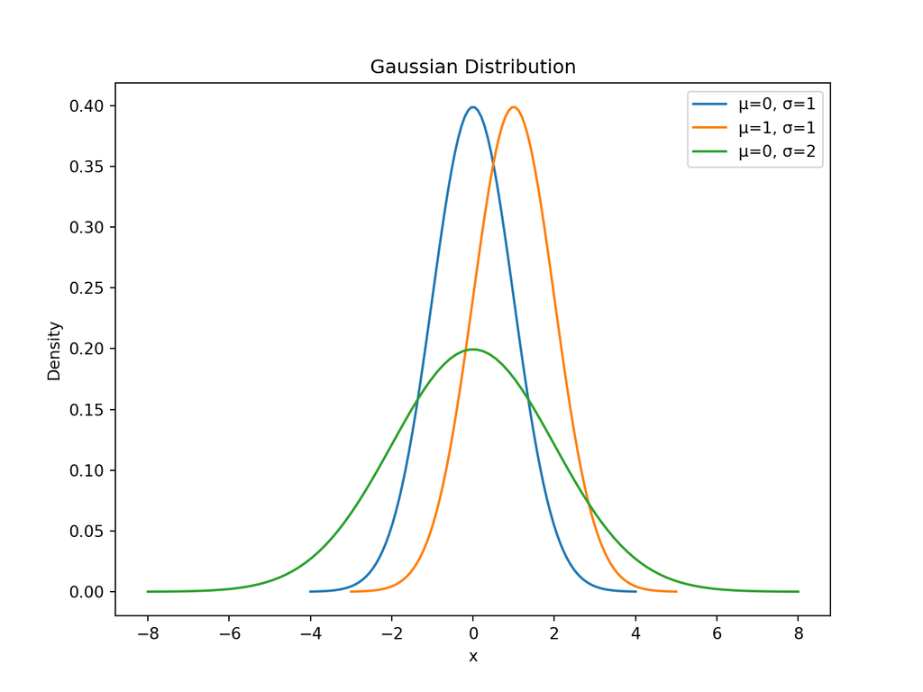

```python
import numpy as np
import matplotlib.pyplot as plt


class Gaussian:
  @staticmethod
  def plot(mean, std, lower_bound=None, upper_bound=None, resolution=None,
    title=None, x_label=None, y_label=None, legend_label=None, legend_location="best"):

    lower_bound = ( mean - 4*std ) if lower_bound is None else lower_bound
    upper_bound = ( mean + 4*std ) if upper_bound is None else upper_bound
    resolution  = 100

    title        = title        or "Gaussian Distribution"
    x_label      = x_label      or "x"
    y_label      = y_label      or "Density"
    legend_label = legend_label or "μ={}, σ={}".format(mean, std)

    X = np.linspace(lower_bound, upper_bound, resolution)
    dist_X = Gaussian._distribution(X, mean, std)

    plt.title(title)

    plt.plot(X, dist_X, label=legend_label)

    plt.xlabel(x_label)
    plt.ylabel(y_label)
    plt.legend(loc=legend_location)

    return plt

  @staticmethod
  def _distribution(X, mean, std):
    return 1./(np.sqrt(2*np.pi)*std)*np.exp(-0.5 * (1./std*(X - mean))**2)

plot = Gaussian.plot(0, 1)
plot = Gaussian.plot(1, 1)
plot = Gaussian.plot(0, 2)
plot.show()
```

# t distribution

$$f(x;v)=\cfrac{\Gamma(\cfrac{v+1}{2})}{\sqrt{v\pi}\Gamma(v/2)}(1+\cfrac{x^2}{v})^{-\cfrac{v+1}{2}}$$

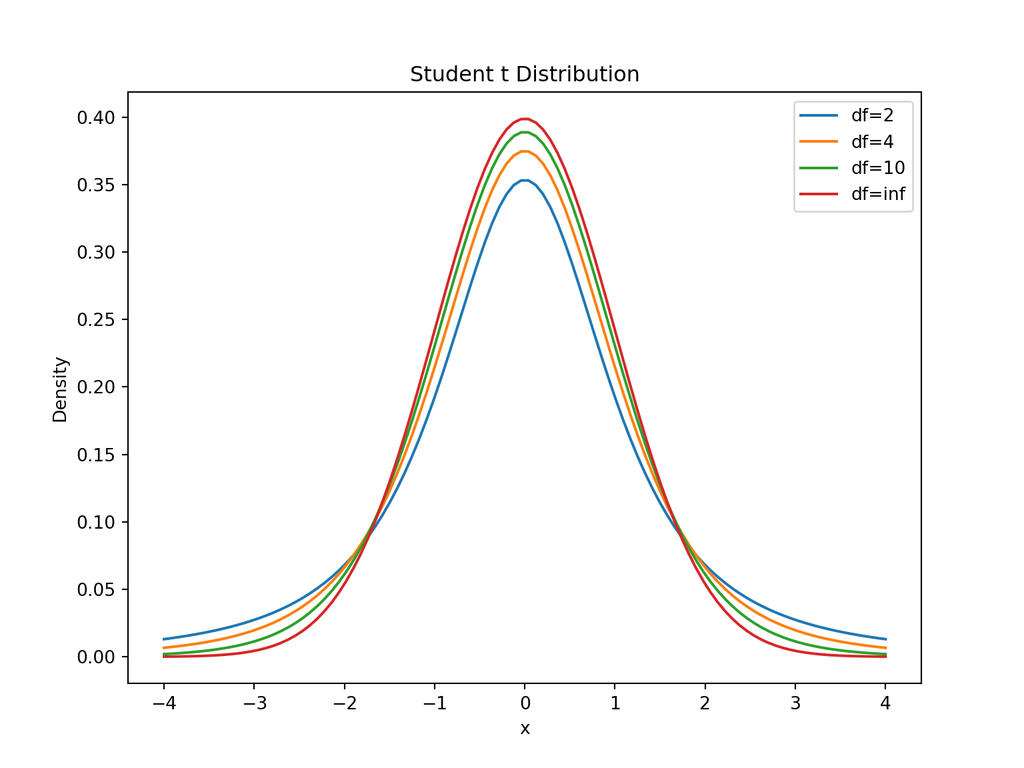

```python
import numpy as np
import matplotlib.pyplot as plt
import scipy.stats


class Student_t:
  @staticmethod
  def plot(df, lower_bound=None, upper_bound=None, resolution=None,
    title=None, x_label=None, y_label=None, legend_label=None, legend_location="best"):

    resolution  = 100

    title        =  "Student t Distribution"
    x_label      =   "x"
    y_label      =  "Density"
    legend_label = legend_label or "df={}".format(df)

    X = np.linspace(lower_bound, upper_bound, resolution)
    dist_X = Student_t._distribution(X, df)

    plt.title(title)

    plt.plot(X, dist_X, label=legend_label)

    plt.xlabel(x_label)
    plt.ylabel(y_label)
    plt.legend(loc=legend_location)

    return plt

  @staticmethod
  def _distribution(X, df):
    return scipy.stats.t.pdf(X, df)

plot = Student_t.plot(2,  lower_bound=-4, upper_bound=4)
plot = Student_t.plot(4,  lower_bound=-4, upper_bound=4)
plot = Student_t.plot(10,  lower_bound=-4, upper_bound=4)
plot = Student_t.plot(float('inf'),  lower_bound=-4, upper_bound=4)
plot.show()
```

# Chi-square distribution

$$f(x;k)=\cfrac{1}{2^{k/2}\Gamma(k/2)}x^{k/2-1}e^{-x/2}$$

```python
import numpy as np
import matplotlib.pyplot as plt
import scipy.stats


class Chi2:
  @staticmethod
  def plot(df, lower_bound=None, upper_bound=None, resolution=None,
    title=None, x_label=None, y_label=None, legend_label=None, legend_location="best"):

    resolution  = 100

    title        =  "Chi-square Distribution"
    x_label      =   "x"
    y_label      =  "Density"
    legend_label = legend_label or "df={}".format(df)

    X = np.linspace(lower_bound, upper_bound, resolution)
    dist_X = Chi2._distribution(X, df)

    plt.title(title)

    plt.plot(X, dist_X, label=legend_label)

    plt.xlabel(x_label)
    plt.ylabel(y_label)
    plt.legend(loc=legend_location)

    return plt

  @staticmethod
  def _distribution(X, df):
    return scipy.stats.chi2.pdf(X, df)

plot = Chi2.plot(1,  lower_bound=0, upper_bound=4)
plot = Chi2.plot(2,  lower_bound=0, upper_bound=4)
plot = Chi2.plot(5,  lower_bound=0, upper_bound=4)
plot = Chi2.plot(10,  lower_bound=0, upper_bound=4)
plt.ylim([0, 1])
```

```
## (0.0, 1.0)
```

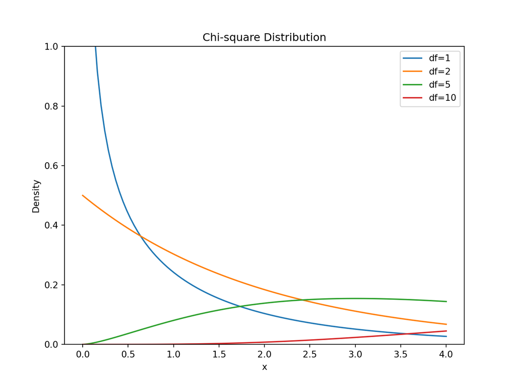

```python
plot.show()
```

# Relationship between Normal distribution and Chi-square distribution

```python
## verification via qq-plot

import random
import numpy as np
import matplotlib.pyplot as plt
import scipy.stats

random.seed(32611)

x1 = np.random.normal(size=1000)
x2 = np.random.chisquare(df=1,size=1000)

x1_sorted = np.sort(np.square(x1))
x2_sorted = np.sort(x2)

plt.xlim([0, 5])
```

```python
plt.ylim([0, 5])
```

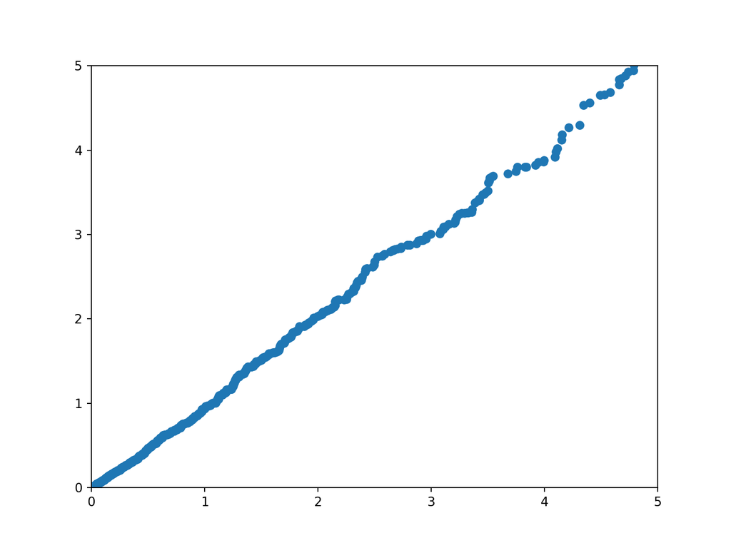

```python
plt.plot(x1_sorted,x2_sorted,"o")
plot.show()
```

# Poisson distribution

$$f(k:\lambda)=\cfrac{\lambda^ke^{-\lambda}}{k!}
(k>0)$$

```python
import numpy as np
import matplotlib.pyplot as plt
import scipy.stats

x = np.arange(0, 10, 0.5)
# poisson distribution data for y-axis
y1 = scipy.stats.poisson.pmf(x, mu=1)
y2 = scipy.stats.poisson.pmf(x, mu=2)
y3 = scipy.stats.poisson.pmf(x, mu=3)
y4 = scipy.stats.poisson.pmf(x, mu=4)

fig, axs = plt.subplots(2, 2)

plt.setp(axs, ylim=(0,.5)) # set y-axis limit
```

```python
axs[0, 0].bar(x, y1,color='black')
```

```python
axs[0, 0].set_title('lambda=1')
axs[0, 1].bar(x, y2,color='red')
```

```python
axs[0, 1].set_title('lambda=2')
axs[1, 0].bar(x, y3,color='green')
```

```python
axs[1, 0].set_title('lambda=3')
axs[1, 1].bar(x, y4)
```

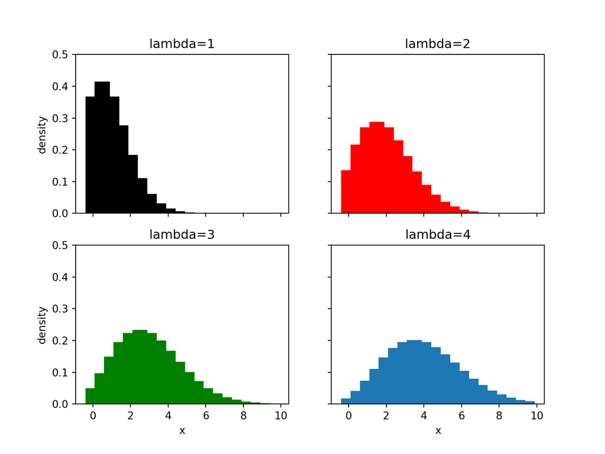

```python
axs[1, 1].set_title('lambda=4')


for ax in axs.flat:
    ax.set(xlabel='x', ylabel='density')

# Hide x labels and tick labels for top plots and y ticks for right plots.
for ax in axs.flat:
    ax.label_outer()
plot.show()
```

# Beta distribution

$$f(x;\alpha,\beta)=\cfrac{\Gamma(\alpha+\beta)}{\Gamma(\alpha)\Gamma(\beta)}x^{\alpha-1}(1-x)^{\beta-1}$$

```python
import numpy as np
import matplotlib.pyplot as plt
import scipy.stats


class Beta:
  @staticmethod
  def plot(a, b, lower_bound=None, upper_bound=None, resolution=None,
    title=None, x_label=None, y_label=None, legend_label=None, legend_location="best"):

    resolution  = 100

    title        =  "Beta Distribution"
    x_label      =   "Proportion (p)"
    y_label      =  "Density"
    legend_label = legend_label or "a={},b={}".format(a,b)

    X = np.linspace(lower_bound, upper_bound, resolution)
    dist_X = Beta._distribution(X, a, b)

    plt.title(title)

    plt.plot(X, dist_X, label=legend_label)

    plt.xlabel(x_label)
    plt.ylabel(y_label)
    plt.legend(loc=legend_location)

    return plt

  @staticmethod
  def _distribution(X, a, b):
    return scipy.stats.beta.pdf(X, a, b)

plot = Beta.plot(a=0.25, b=0.25, lower_bound=0, upper_bound=1)
plot = Beta.plot(a=2, b=2,  lower_bound=0, upper_bound=1)
plot = Beta.plot(a=2, b=5,  lower_bound=0, upper_bound=1)
plot = Beta.plot(a=12, b=2, lower_bound=0, upper_bound=1)
plot = Beta.plot(a=20, b=0.75, lower_bound=0, upper_bound=1)
plot = Beta.plot(a=1, b=1, lower_bound=0, upper_bound=1)
plt.ylim([0, 6])
```

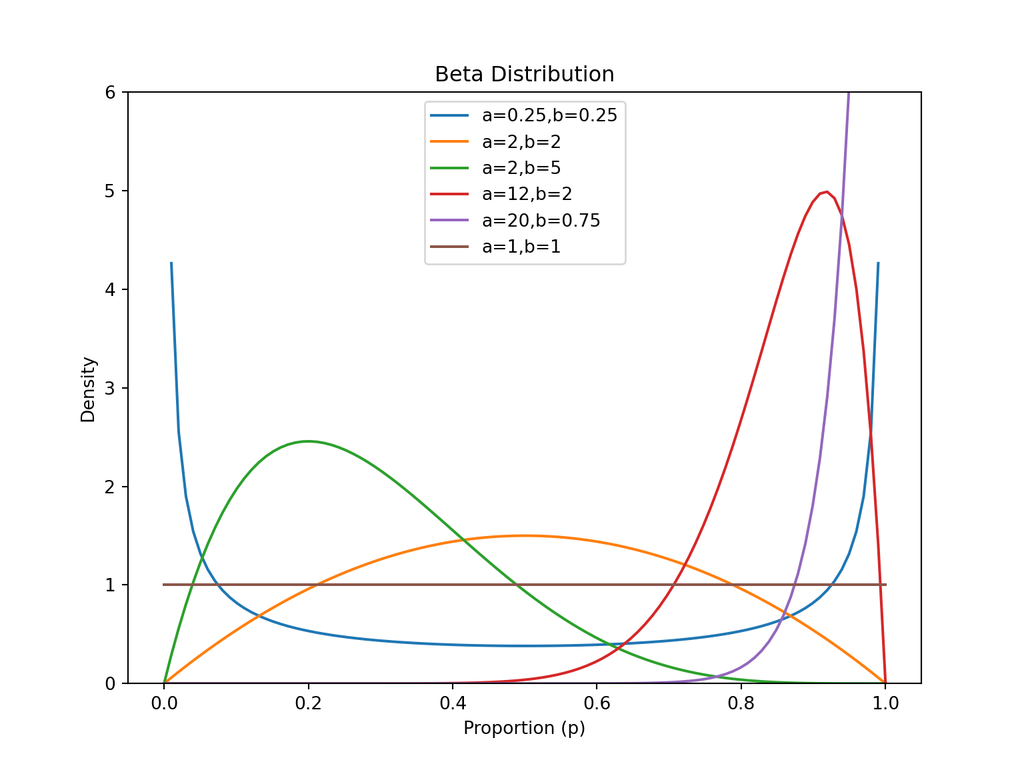

```python
plot.show()
```

# Beta distribution properties

- $x \sim Beta(\alpha,\beta)$.
- $E(X)=\cfrac{\alpha}{\alpha+\beta}$.
- $Var(X)=\cfrac{\alpha\beta}{(\alpha+\beta)^2(\alpha+\beta+1)}$.
- When $\alpha=\beta=1$, Beta distribution reduces to Unif(0,1).

# Samples from Normal distribution

```python
import random
import numpy as np
import matplotlib.pyplot as plt
from scipy.stats import norm
from numpy import linspace
from scipy.stats.kde import gaussian_kde
```

```python
random.seed(32611)
z = np.random.normal(size=1000) ## generate 1000 samples from N(0,1).
plt.hist(x=z, bins=50, color='gray',alpha=0.7, rwidth=0.8, density=True)

# plot theoritical pdf
```

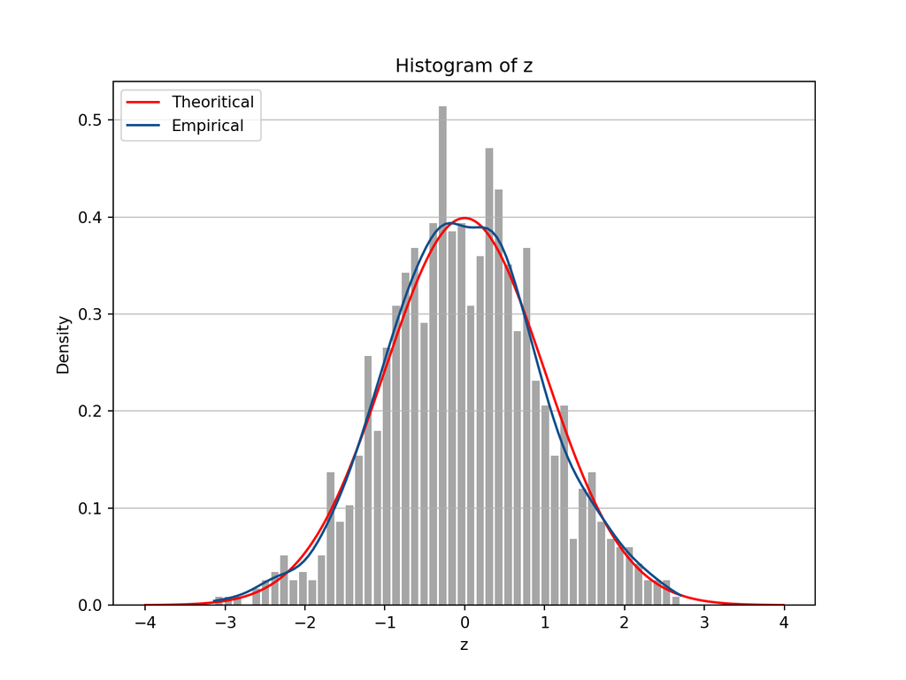

```python
x_axis = np.arange(-4, 4, 0.01)
plt.plot(x_axis, norm.pdf(x_axis, 0, 1),color='red',label='Theoritical')

# plot empirical pdf
kde = gaussian_kde(z)
dist_space = linspace( min(z), max(z), 100 )
plt.plot(dist_space, kde(dist_space), color='#104E8B',label='Empirical')

plt.legend(loc="upper left")
plt.grid(axis='y', alpha=0.75)
plt.xlabel('z')
plt.ylabel('Density')
plt.title('Histogram of z')
plt.show()
```

# Check CDF

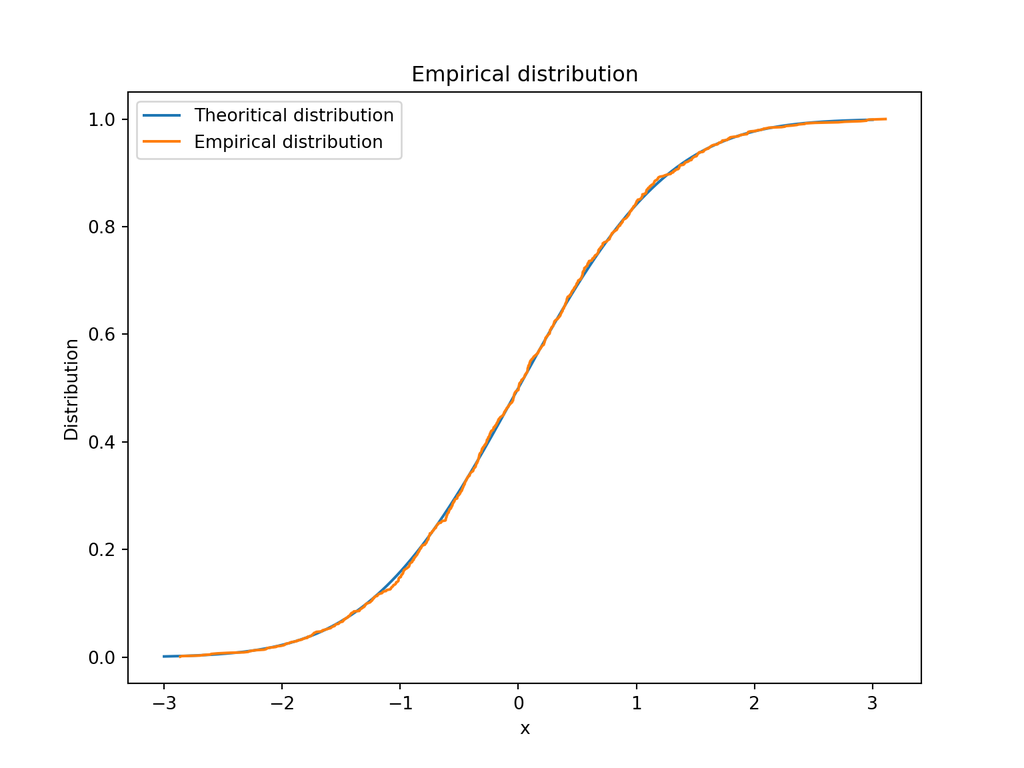

```python
import random
import numpy as np
import matplotlib.pyplot as plt
import scipy.stats
from statsmodels.distributions.empirical_distribution import ECDF

random.seed(32611)
z = np.random.normal(size=1000) ## generate 1000 samples from N(0,1).



# plot theoritical cdf
x = np.linspace(-3, 3, 1000)
y = scipy.stats.norm.cdf(x)
plt.plot(x, y,label='Theoritical distribution')

# plot empirical distribution
ecdf = ECDF(z)
plt.plot(ecdf.x, ecdf.y, label='Empirical distribution')

plt.legend(loc="upper left")
plt.xlabel('x')
plt.ylabel('Distribution')
plt.title('Empirical distribution')
plt.show()
```

# p-value

- p-value: The probability that the null statistic is as extreme or more extreme than the observed statistic, when null hypothesis is true.
- p-value is the cumulative density. It can be computed by scipy.stats.norm.cdf (Normal distribution) in python.
- Example: observed Z value equals to 2 with null distribution is $N(0,1)$.

```python
import scipy.stats

2*(1-scipy.stats.norm.cdf(2)) ## Two-sided test
```

```
## 0.04550026389635842
```

```python
1-scipy.stats.norm.cdf(2) ## One-sided test
```

```
## 0.02275013194817921
```

# Quantile

scipy.stats.norm.ppf(): return the quantile of input area under the density curve (cumulative density).

```python
import scipy.stats

scipy.stats.norm.ppf(0.975)
```

```
## 1.959963984540054
```

```python
scipy.stats.norm.ppf(.025)
```

```
## -1.9599639845400545
```

```python
scipy.stats.norm.ppf(.5)
```

```
## 0.0
```

# Commonly used statistical tests

- T test
- Wilcox rank test
- Chi-squre test
- Fisher’s exact test
- Correlation test
- KS test

# One-sample T test

- Test if the group mean is different from 0.
- $H_0$: mean value of a group is 0 ($\mu$=0).

```python
import random
import numpy as np
import scipy.stats

random.seed(32611)
group = np.random.normal(size=10)

scipy.stats.ttest_1samp(group,popmean=0)
```

```
## Ttest_1sampResult(statistic=-0.6614544529945775, pvalue=0.5248914967671621)
```

# Two-sample T test

- To compare the mean values of two samples that are normally distributed.
- $H_0$: mean values of two samples are same ($\mu_1=\mu_2$).

```python
import random
import numpy as np
import scipy.stats

random.seed(32611)
group1 = np.random.normal(size=10)
group2 = np.random.normal(size=10,loc=1.2)

scipy.stats.ttest_ind(group1,group2)
```

```
## Ttest_indResult(statistic=-2.266670352590246, pvalue=0.035968786155763904)
```

# Two-sample paired T test

- When your data are in matched pairs.
- $H_0$: mean values of two samples are same ($\mu_{pre}=\mu_{post}$).

```python
import random
import numpy as np
import scipy.stats

random.seed(32611)
pre = np.random.normal(size=10)
post = np.random.normal(size=10,loc=1.2)

scipy.stats.ttest_rel(pre,post)
```

```
## Ttest_relResult(statistic=-1.8481615702478376, pvalue=0.09763614058789771)
```

# Two-sample Wilcox Rank Sum test

- To compare the median values of two samples without any distribution assumption.
- Non-parametric test.
- $H_0$: median values of two samples are same.

```python
import random
import numpy as np
import scipy.stats

random.seed(32611)
group1 = np.random.normal(size=10)
group2 = np.random.normal(size=10,loc=1.2)

scipy.stats.ranksums(group1, group2)
```

```
## RanksumsResult(statistic=-3.4016802570830453, pvalue=0.0006697294490218271)
```

# Two-sample paired Wilcox Rank Sum test

- When your data are in matched pairs.
- $H_0$: median values of two samples are same.

```python
import random
import numpy as np
import scipy.stats

random.seed(32611)
group1 = np.random.normal(size=10)
group2 = np.random.normal(size=10,loc=1.2)

scipy.stats.wilcoxon(group1, group2)
```

```
## WilcoxonResult(statistic=8.0, pvalue=0.048828125)
```

# Chi-square test

```
##          Disease
## Treatment Y   N
##         Y "a" "c"
##         N "b" "d"
```

- Test for independence
- $H_0$: the treatment effects are same between treatment group and control group.
- Note that:
  - All expected counts should be greater than 5.
  - Can be applied to tables with more than 2 categories.
- Example: relationship between myocardial infarction and aspirin use (Agresti 1996).

```
##          Myocardial Infarction
## Treatment Yes    No
##   Placebo 189 10845
##   Aspirin 104 10933
```

```python
from scipy.stats import chi2_contingency

observed = [[189, 10845], [104,10933]]
chi2_contingency(observed)

## Output details
#(test statistic, p-value, df, expected frequencies)
```

```
## (24.42905651522594, 7.709707547507586e-07, 1, array([[  146.48008699, 10887.51991301],
##        [  146.51991301, 10890.48008699]]))
```

# Fisher’s exact test

- Test for independence.
- No approximation. (When more than 20% of cells have expected frequencies < 5.)
- $H_0$: the treatment effects are same between treatment group and control group.

```
##          Myocardial Infarction
## Treatment Yes    No
##   Placebo 189 10845
##   Aspirin 104 10933
```

```python
from scipy.stats import fisher_exact

observed = [[189, 10845], [104,10933]]
scipy.stats.fisher_exact(observed)

## Output details
#(odds ratio, p-value)
```

```
## (1.8320539419087136, 5.032835599722745e-07)
```

# Correlation test

- Test if there is a correlation between vector a and b.
- $H_0: \rho_1=\rho_2$.

```python
import random
import numpy as np
import scipy.stats

random.seed(32611)
group1 = np.random.normal(size=10)
group2 = np.random.normal(size=10,loc=1.2)

scipy.stats.pearsonr(group1,group2) # Pearson correlation: requires Gaussian assumption.
```

```
## PearsonRResult(statistic=-0.10791319674825095, pvalue=0.7666697087978418)
```

```python
scipy.stats.spearmanr(group1,group2) # Spearman correlation: non-parametric, no distribution assumption needed.
```

```
## SpearmanrResult(correlation=-0.22424242424242422, pvalue=0.5334005612725947)
```

# Kolmogorov-Smirnov (KS) test

- Test if random variables X and Y are from the same distribution.
- $H_0$: X and Y are from the same distribution.

```python
import random
import numpy as np
import scipy.stats

random.seed(32611)
group1 = np.random.normal(size=50) # N(0,1)
group2 = np.random.normal(size=50,loc=1.2) # N(1.2,1)


scipy.stats.kstest(group1, group2)
```

```
## KstestResult(statistic=0.56, pvalue=1.4534580579142488e-07)
```

# Fit linear model in Python

- sklearn

```python
import pandas as pd
import numpy as np
from sklearn import metrics
from sklearn.linear_model import LinearRegression
from sklearn.metrics import r2_score
import pandas as pd

mtcars = pd.read_csv("https://vincentarelbundock.github.io/Rdatasets/csv/datasets/mtcars.csv", index_col=0)

#Setting response and predictors
y = mtcars.mpg
X = mtcars[["cyl"]]

#Fitting simple Linear Regression Model
linr_model = LinearRegression().fit(X, y)

#Model Fitting Results
print('estimated slope (cly)', 'estimated intercept', 'R-square')
```

[output not shown]

```python
print(linr_model.intercept_, linr_model.coef_[0],linr_model.score(X,y))
```

```
## 37.88457648546145 -2.875790139064476 0.7261800050938048
```

- Interpretation
  - One unit increase in cyl will result in 2.88 decrease in mpg on average.
  - 0.726 denoted that 72.6% of the variability is explained by the model, which means the predicted values are 72.6% close to the actual mpg values.
- Making Predictions based on the estimated slope and intercept.
  - Cylinders.

```python
mtcars[["cyl"]].head(10)
```

```
##                    cyl
## Mazda RX4            6
## Mazda RX4 Wag        6
## Datsun 710           4
## Hornet 4 Drive       6
## Hornet Sportabout    8
## Valiant              6
## Duster 360           8
## Merc 240D            4
## Merc 230             4
## Merc 280             6
```

- Predicted mpgs.

```python
linr_model.predict(mtcars[["cyl"]])[0:10]
```

```
## array([20.62983565, 20.62983565, 26.38141593, 20.62983565, 14.87825537,
##        20.62983565, 14.87825537, 26.38141593, 26.38141593, 20.62983565])
```

- statsmodels

```python
import statsmodels.api as sm

#define response variable
y = mtcars['mpg']

#define predictor variables
x = mtcars[['cyl']]

#add constant to predictor variables
x = sm.add_constant(x)

#fit linear regression model
model1 = sm.OLS(y, x).fit()

#view model summary
print(model1.summary())
```

```
##                             OLS Regression Results
## ==============================================================================
## Dep. Variable:                    mpg   R-squared:                       0.726
## Model:                            OLS   Adj. R-squared:                  0.717
## Method:                 Least Squares   F-statistic:                     79.56
## Date:                Mon, 28 Nov 2022   Prob (F-statistic):           6.11e-10
## Time:                        20:45:15   Log-Likelihood:                -81.653
## No. Observations:                  32   AIC:                             167.3
## Df Residuals:                      30   BIC:                             170.2
## Df Model:                           1
## Covariance Type:            nonrobust
## ==============================================================================
##                  coef    std err          t      P>|t|      [0.025      0.975]
## ------------------------------------------------------------------------------
## const         37.8846      2.074     18.268      0.000      33.649      42.120
## cyl           -2.8758      0.322     -8.920      0.000      -3.534      -2.217
## ==============================================================================
## Omnibus:                        1.007   Durbin-Watson:                   1.670
## Prob(Omnibus):                  0.604   Jarque-Bera (JB):                0.874
## Skew:                           0.380   Prob(JB):                        0.646
## Kurtosis:                       2.720   Cond. No.                         24.1
## ==============================================================================
##
## Notes:
## [1] Standard Errors assume that the covariance matrix of the errors is correctly specified.
```

- Response: mpg.
- Predictors: cyl, disp.

```python
y = mtcars['mpg']
x = mtcars[['cyl','disp']]
x = sm.add_constant(x)
model2 = sm.OLS(y, x).fit()
print(model2.summary())
```

```
##                             OLS Regression Results
## ==============================================================================
## Dep. Variable:                    mpg   R-squared:                       0.760
## Model:                            OLS   Adj. R-squared:                  0.743
## Method:                 Least Squares   F-statistic:                     45.81
## Date:                Mon, 28 Nov 2022   Prob (F-statistic):           1.06e-09
## Time:                        20:45:16   Log-Likelihood:                -79.573
## No. Observations:                  32   AIC:                             165.1
## Df Residuals:                      29   BIC:                             169.5
## Df Model:                           2
## Covariance Type:            nonrobust
## ==============================================================================
##                  coef    std err          t      P>|t|      [0.025      0.975]
## ------------------------------------------------------------------------------
## const         34.6610      2.547     13.609      0.000      29.452      39.870
## cyl           -1.5873      0.712     -2.230      0.034      -3.043      -0.131
## disp          -0.0206      0.010     -2.007      0.054      -0.042       0.000
## ==============================================================================
## Omnibus:                        3.200   Durbin-Watson:                   1.596
## Prob(Omnibus):                  0.202   Jarque-Bera (JB):                2.660
## Skew:                           0.701   Prob(JB):                        0.264
## Kurtosis:                       2.822   Cond. No.                     1.27e+03
## ==============================================================================
##
## Notes:
## [1] Standard Errors assume that the covariance matrix of the errors is correctly specified.
## [2] The condition number is large, 1.27e+03. This might indicate that there are
## strong multicollinearity or other numerical problems.
```

- Response: mpg.
- Predictors: all variables but the response (mpg).

```python
y = mtcars['mpg']
x = mtcars.loc[:, mtcars.columns != 'mpg'] # exclude mpg
x = sm.add_constant(x)
model3 = sm.OLS(y, x).fit()
print(model3.summary())
```

```
##                             OLS Regression Results
## ==============================================================================
## Dep. Variable:                    mpg   R-squared:                       0.869
## Model:                            OLS   Adj. R-squared:                  0.807
## Method:                 Least Squares   F-statistic:                     13.93
## Date:                Mon, 28 Nov 2022   Prob (F-statistic):           3.79e-07
## Time:                        20:45:17   Log-Likelihood:                -69.855
## No. Observations:                  32   AIC:                             161.7
## Df Residuals:                      21   BIC:                             177.8
## Df Model:                          10
## Covariance Type:            nonrobust
## ==============================================================================
##                  coef    std err          t      P>|t|      [0.025      0.975]
## ------------------------------------------------------------------------------
## const         12.3034     18.718      0.657      0.518     -26.623      51.229
## cyl           -0.1114      1.045     -0.107      0.916      -2.285       2.062
## disp           0.0133      0.018      0.747      0.463      -0.024       0.050
## hp            -0.0215      0.022     -0.987      0.335      -0.067       0.024
## drat           0.7871      1.635      0.481      0.635      -2.614       4.188
## wt            -3.7153      1.894     -1.961      0.063      -7.655       0.224
## qsec           0.8210      0.731      1.123      0.274      -0.699       2.341
## vs             0.3178      2.105      0.151      0.881      -4.059       4.694
## am             2.5202      2.057      1.225      0.234      -1.757       6.797
## gear           0.6554      1.493      0.439      0.665      -2.450       3.761
## carb          -0.1994      0.829     -0.241      0.812      -1.923       1.524
## ==============================================================================
## Omnibus:                        1.907   Durbin-Watson:                   1.861
## Prob(Omnibus):                  0.385   Jarque-Bera (JB):                1.747
## Skew:                           0.521   Prob(JB):                        0.418
## Kurtosis:                       2.526   Cond. No.                     1.22e+04
## ==============================================================================
##
## Notes:
## [1] Standard Errors assume that the covariance matrix of the errors is correctly specified.
## [2] The condition number is large, 1.22e+04. This might indicate that there are
## strong multicollinearity or other numerical problems.
```